# Setting up Your Python Enviroment

## Overview

## Overview

- This lecture is intended to be the first step on your Python journey. In it you will learn how to
  1. get a Python environment up and running with all the necessary tools
  2. execute basic Python commands
  3. run a sample program
  4. install the Python programs that underpin these lectures

## Choices

- There are many, many ways to interact with Python.
- We are going to introduce one of them, based around the IPython notebook
- This is an excellent tool for both beginners and experts, and a great way to get programming quickly

## First Steps

## First Steps

- By far the best approach for our purposes is to install one of the free Python distributions that contains
  - the core Python language and
  - the most popular scientific libraries
- There are several such distributions
- Of them our experiences lead us to recommend Anaconda

## Installing Anaconda

- Installing Anaconda is straightforward: [download the binary](http://docs.continuum.io/anaconda/index) and follow the instructions
- **Important**: If you are asked during the installation process whether you'd like to make Anaconda your default Python installation, say yes
- Otherwise you can accept all of the defaults
- Remember to choose the version for Python 3.x

## Keeping Anaconda up to Date

- The packages in Anaconda update regularly so it's important to keep your distribution up to date
- As a practice run, please execute the following
  1. Open up a terminal
  2. Type `conda update anaconda`

## Get a Modern Browser

- Now is probably a good time to either
  - update your browser or
  - install a free modern browser such as Chrome or Firefox
- Once you've done that we can fire up IPython notebook and start having fun

## IPython Notebook

## IPython Notebook

- The IPython notebook provides a **browser-based** interface to Python with
  - The ability to write and execute Python commands directly in your browser
  - Nicely formatted output also in the browser, including tables, figures, animation, video, etc.
  - The ability to mix in formatted text and mathematical expressions between cells

## Notebook Basics

- The next thing to understand about the IPython notebook is that it uses a modal editing system
- This means that the effect of typing at the keyboard **depends on which mode you are in**

## Notebook Basics

- Switching modes
  - To switch to command mode from edit mode, hit the Esc key
  - To switch to edit mode from command mode, hit Enter or click in a cell
- The modal behavior of the IPython notebook is a little tricky at first but very efficient when you get used to it

## A Test Program

```python
import numpy as np
import matplotlib.pyplot as plt
N = 50
x = np.random.rand(N)
y = np.random.rand(N)
area = np.pi * (15 * np.random.rand(N))**2 # 0 to 15 point radiuses
plt.scatter(x, y, s=area, alpha=0.5)
plt.show()
```

## A Test Program

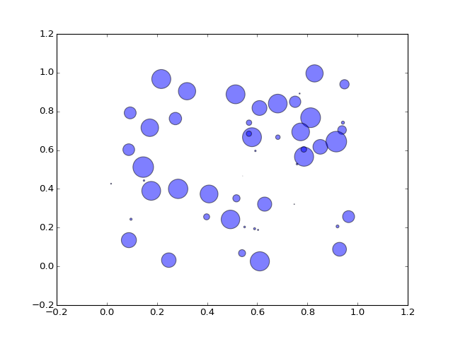

## Working with the Notebook

- One nice feature of IPython is tab completion
- For example, in the previous program we executed the line `import numpy as np`
- NumPy is a numerical library we'll work with in depth
- Functions in NumPy can be accessed with `np.<function_name>` type syntax (assuming you've executed `import numpy as np`)
- One way to explore these functions is to type in a cell `np.<start_of_word>` and hit the tab key
- To get help on `np.rank`, say, we can execute `np.rank?`

## Sharing Notebooks

- A notebook can easily be saved and shared between users
- Notebook files are just text files and typically ending with .ipynb

## Additional Software

## Additional Software

- Along with a number of collaborators, there are some software that is useful for solving economic problems
- In fact this set of files has been organized into a package
- In Python, a package is a software library - a collection of programs that have been bundled for distribution
- You can install the package by copying and pasting the following into a **system terminal**: `pip install quantecon`

## Working with Python Files

- How does one run and experiment with an existing Python file using the notebook?
- For short files you can just copy and paste them into a cell
- For longer files, you can run the code in the file in two steps
  - navigate to the correct directory
  - type `run` followed by the file name

## Navigating to a Directory

- IPython notebook has a notion of apresent working directorya where it looks for files that you refer to during an IPython session
- If you're trying to run a file not in the pwd (present working directory), you typically want to change the pwd to the location of the file

## Load vs Run

- It's often convenient to be able to see your code before you run it.
- For this purpose we can replace `run file_name.py` with `load file_name.py` and then execute
- When we do this the code from the file appears in a cell ready to execute

## Saving Files

- To save the contents of a cell as file `foo.py`, put `%%file foo.py` as the first line of the cell and then Shift + Enter
- Here `%%file` is an example of an IPython cell magic

## Alternatives

## Alternatives

- The preceding discussion covers most of what you need to know to write and run Python code
- However, as you start to write longer programs, you might want to experiment with your workflow
- There are many different options and we cover only a few.

## Text Editors

- One thing we find is that nothing beats the power and efficiency of a good text editor for working with program text
- A text editor is an application that is specifically designed to work with text files - such as Python programs
- A good text editor will provide syntax highlighting and allow you to search and replace, indent blocks of code, etc., etc.

## Text Editors

- One that we recommend is Sublime Text, a popular and highly regarded text editor with a relatively moderate learning curve
- Sublime Text is not free, but it does have an unlimited trial period, so you can take your time and see if you like it

## Text Editors

- There are many others, and a lot of them are free - you can find out more by googling for Python text editors
- If you want a top quality free editor and don't mind a sharper learning curve, try Emacs
- If you want an outstanding free text editor and don't mind a seemingly vertical learning curve plus long days of pain and suffering while all your neural pathways are rewired, try Vim

## Text Editors Plus IPython

- A good work flow for longer projects is to have an IPython notebook session and a text editor open side by side
- The text editor contains whatever programs are currently being edited
- To run them we switch to IPython notebook and type run filename.py in a cell
- You can also experiment with bits of code in notebook cells and copy and paste into the main program via the text editor when you're satisfied

## IPython Shell vs IPython Notebook

- If you're working with a text editor, you can also run Python programs in an ordinary IPython shell rather than an IPython notebook
- To use an IPython shell, open up a terminal and type `ipython`
- The IPython shell has many of the features of the notebook: tab completion, color syntax, etc.

## IPython Shell vs IPython Notebook

- It also has command history through the arrow key
  - Type any command, such as `print('foo')`
  - Now hit the up arrow key, and then return
- The up arrow brings the previously typed command to the prompt. This saves a lot of typing…

## Exercises

## Exercises

- Try to launching IPython Notebook again, but this time using `ipython notebook --no-browser`
- This should start the kernel without launching the browser
- Note also the startup message: It should give you a URL such as http://127.0.0.1:8888 where the notebook is running

## Exercises

- Now
  - Start your browser - or open a new tab if it's already running
  - Enter the URL from above (e.g. http://127.0.0.1:8888) in the address bar at the top
- You should now be able to run a standard IPython notebook session
- This is an alternative way to start the notebook that can also be handy